# Predict Bike Sharing Demand with AutoGluon Template

## Project: Predict Bike Sharing Demand with AutoGluon

This notebook is a template with each step that you need to complete for the project.

Please fill in your code where there are explicit `?` markers in the notebook. You are welcome to add more cells and code as you see fit.

Once you have completed all the code implementations, please export your notebook as a HTML file so the reviews can view your code. Make sure you have all outputs correctly outputted.

`File-> Export Notebook As... -> Export Notebook as HTML`

There is a writeup to complete as well after all code implememtation is done. Please answer all questions and attach the necessary tables and charts. You can complete the writeup in either markdown or PDF.

Completing the code template and writeup template will cover all of the rubric points for this project.

The rubric contains "Stand Out Suggestions" for enhancing the project beyond the minimum requirements. The stand out suggestions are optional. If you decide to pursue the "stand out suggestions", you can include the code in this notebook and also discuss the results in the writeup file.

## Step 1: Create an account with Kaggle

### Create Kaggle Account and download API key

Below is example of steps to get the API username and key. Each student will have their own username and key.

1. Open account settings.

2. Scroll down to API and click Create New API Token.

3. Open up `kaggle.json` and use the username and key.


## Step 2: Download the Kaggle dataset using the kaggle python library

### Open up Sagemaker Studio and use starter template

1. Notebook should be using a `ml.t3.medium` instance (2 vCPU + 4 GiB)
2. Notebook should be using kernal: `Python 3 (MXNet 1.8 Python 3.7 CPU Optimized)`

### Install packages

```python
!pip install -U pip
!pip install -U setuptools wheel
!pip install -U "mxnet<2.0.0" bokeh==2.0.1
```

```
  Using cached pip-25.1.1-py3-none-any.whl.metadata (3.6 kB)
Using cached pip-25.1.1-py3-none-any.whl (1.8 MB)
```

[output not shown]

```
  Using cached mxnet-1.7.0.post2-py2.py3-none-win_amd64.whl.metadata (402 bytes)
  Using cached bokeh-2.0.1.tar.gz (8.6 MB)
  Preparing metadata (setup.py): started
  Preparing metadata (setup.py): finished with status 'error'
```

[output not shown]

```python
!pip install autogluon
```

### Download and explore dataset

### Go to the bike sharing demand competition and agree to the terms

```python
import pandas as pd
from autogluon.tabular import TabularPredictor
```

```python
# Download the dataset, it will be in a .zip file so you'll need to unzip it as well.
!kaggle competitions download -c bike-sharing-demand
# If you already downloaded it you can use the -o command to overwrite the file
!unzip -o bike-sharing-demand.zip
```

```
Downloading bike-sharing-demand.zip to C:\Users\User\Downloads\Chit Zin Win-Udacity
```

```
Archive:  bike-sharing-demand.zip
  inflating: sampleSubmission.csv
  inflating: test.csv
  inflating: train.csv
```

```python
# Create the train dataset in pandas by reading the csv
# Set the parsing of the datetime column so you can use some of the `dt` features in pandas later
train = pd.read_csv("train.csv", parse_dates = ["datetime"])
train.head()
```

|  | datetime | season | holiday | workingday | weather | temp | atemp | humidity | windspeed | casual | registered | count |
| --- | --- | --- | --- | --- | --- | --- | --- | --- | --- | --- | --- | --- |
| 0 | 2011-01-01 00:00:00 | 1 | 0 | 0 | 1 | 9.84 | 14.395 | 81 | 0.0 | 3 | 13 | 16 |
| 1 | 2011-01-01 01:00:00 | 1 | 0 | 0 | 1 | 9.02 | 13.635 | 80 | 0.0 | 8 | 32 | 40 |
| 2 | 2011-01-01 02:00:00 | 1 | 0 | 0 | 1 | 9.02 | 13.635 | 80 | 0.0 | 5 | 27 | 32 |
| 3 | 2011-01-01 03:00:00 | 1 | 0 | 0 | 1 | 9.84 | 14.395 | 75 | 0.0 | 3 | 10 | 13 |
| 4 | 2011-01-01 04:00:00 | 1 | 0 | 0 | 1 | 9.84 | 14.395 | 75 | 0.0 | 0 | 1 | 1 |

```python
# Simple output of the train dataset to view some of the min/max/varition of the dataset features.
train.describe()
```

|  | datetime | season | holiday | workingday | weather | temp | atemp | humidity | windspeed | casual | registered | count |
| --- | --- | --- | --- | --- | --- | --- | --- | --- | --- | --- | --- | --- |
| count | 10886 | 10886.000000 | 10886.000000 | 10886.000000 | 10886.000000 | 10886.00000 | 10886.000000 | 10886.000000 | 10886.000000 | 10886.000000 | 10886.000000 | 10886.000000 |
| mean | 2011-12-27 05:56:22.399411968 | 2.506614 | 0.028569 | 0.680875 | 1.418427 | 20.23086 | 23.655084 | 61.886460 | 12.799395 | 36.021955 | 155.552177 | 191.574132 |
| min | 2011-01-01 00:00:00 | 1.000000 | 0.000000 | 0.000000 | 1.000000 | 0.82000 | 0.760000 | 0.000000 | 0.000000 | 0.000000 | 0.000000 | 1.000000 |
| 25% | 2011-07-02 07:15:00 | 2.000000 | 0.000000 | 0.000000 | 1.000000 | 13.94000 | 16.665000 | 47.000000 | 7.001500 | 4.000000 | 36.000000 | 42.000000 |
| 50% | 2012-01-01 20:30:00 | 3.000000 | 0.000000 | 1.000000 | 1.000000 | 20.50000 | 24.240000 | 62.000000 | 12.998000 | 17.000000 | 118.000000 | 145.000000 |
| 75% | 2012-07-01 12:45:00 | 4.000000 | 0.000000 | 1.000000 | 2.000000 | 26.24000 | 31.060000 | 77.000000 | 16.997900 | 49.000000 | 222.000000 | 284.000000 |
| max | 2012-12-19 23:00:00 | 4.000000 | 1.000000 | 1.000000 | 4.000000 | 41.00000 | 45.455000 | 100.000000 | 56.996900 | 367.000000 | 886.000000 | 977.000000 |
| std | NaN | 1.116174 | 0.166599 | 0.466159 | 0.633839 | 7.79159 | 8.474601 | 19.245033 | 8.164537 | 49.960477 | 151.039033 | 181.144454 |

```python
# Create the test pandas dataframe in pandas by reading the csv, remember to parse the datetime!
test = pd.read_csv("test.csv", parse_dates = ["datetime"])
test.head()
```

|  | datetime | season | holiday | workingday | weather | temp | atemp | humidity | windspeed |
| --- | --- | --- | --- | --- | --- | --- | --- | --- | --- |
| 0 | 2011-01-20 00:00:00 | 1 | 0 | 1 | 1 | 10.66 | 11.365 | 56 | 26.0027 |
| 1 | 2011-01-20 01:00:00 | 1 | 0 | 1 | 1 | 10.66 | 13.635 | 56 | 0.0000 |
| 2 | 2011-01-20 02:00:00 | 1 | 0 | 1 | 1 | 10.66 | 13.635 | 56 | 0.0000 |
| 3 | 2011-01-20 03:00:00 | 1 | 0 | 1 | 1 | 10.66 | 12.880 | 56 | 11.0014 |
| 4 | 2011-01-20 04:00:00 | 1 | 0 | 1 | 1 | 10.66 | 12.880 | 56 | 11.0014 |

```python
# Same thing as train and test dataset
submission = pd.read_csv("sampleSubmission.csv", parse_dates = ["datetime"])
submission.head()
```

|  | datetime | count |
| --- | --- | --- |
| 0 | 2011-01-20 00:00:00 | 0 |
| 1 | 2011-01-20 01:00:00 | 0 |
| 2 | 2011-01-20 02:00:00 | 0 |
| 3 | 2011-01-20 03:00:00 | 0 |
| 4 | 2011-01-20 04:00:00 | 0 |

## Step 3: Train a model using AutoGluon’s Tabular Prediction

Requirements:

- We are prediting `count`, so it is the label we are setting.
- Ignore `casual` and `registered` columns as they are also not present in the test dataset.
- Use the `root_mean_squared_error` as the metric to use for evaluation.
- Set a time limit of 10 minutes (600 seconds).
- Use the preset `best_quality` to focus on creating the best model.

```python
predictor = TabularPredictor(label = "count", problem_type = "regression", eval_metric = "root_mean_squared_error").fit(train_data=train.drop(columns = ["casual","registered"]), time_limit=600, presets="best_quality")
```

[output not shown]

[output cut: 48 more lines]

[output not shown]

```
(_ray_fit pid=1244) [1000]	valid_set's rmse: 134.479
```

[output not shown]

[output cut: 241 more lines]

```
Fitting model: RandomForestMSE_BAG_L2 ... Training model for up to 40.06s of the 39.90s of remaining time.
	-53.464	 = Validation score   (-root_mean_squared_error)
	25.34s	 = Training   runtime
	1.25s	 = Validation runtime
Fitting model: CatBoost_BAG_L2 ... Training model for up to 12.64s of the 12.48s of remaining time.
	Memory not enough to fit 8 folds in parallel. Will train 4 folds in parallel instead (Estimated 17.88% memory usage per fold, 71.52%/80.00% total).
	Fitting 8 child models (S1F1 - S1F8) | Fitting with ParallelLocalFoldFittingStrategy (4 workers, per: cpus=2, gpus=0, memory=17.88%)
	Time limit exceeded... Skipping CatBoost_BAG_L2.
Fitting model: WeightedEnsemble_L3 ... Training model for up to 360.00s of the -2.61s of remaining time.
	Ensemble Weights: {'RandomForestMSE_BAG_L2': 0.696, 'LightGBM_BAG_L2': 0.261, 'LightGBMXT_BAG_L2': 0.043}
	-53.1227	 = Validation score   (-root_mean_squared_error)
	0.11s	 = Training   runtime
	0.0s	 = Validation runtime
AutoGluon training complete, total runtime = 432.89s ... Best model: WeightedEnsemble_L3 | Estimated inference throughput: 53.4 rows/s (1361 batch size)
TabularPredictor saved. To load, use: predictor = TabularPredictor.load("C:\Users\User\Downloads\cd0385-project-starter-main\cd0385-project-starter-main\project\AutogluonModels\ag-20250525_161540")
```

### Review AutoGluon's training run with ranking of models that did the best.

```python
predictor.fit_summary()
```

```
*** Summary of fit() ***
Estimated performance of each model:
                     model   score_val              eval_metric  pred_time_val    fit_time  pred_time_val_marginal  fit_time_marginal  stack_level  can_infer  fit_order
0      WeightedEnsemble_L3  -53.122679  root_mean_squared_error      27.849534  302.295935                0.002052           0.105764            3       True         13
1   RandomForestMSE_BAG_L2  -53.464036  root_mean_squared_error      17.619033  254.541098                1.251851          25.340600            2       True         12
2          LightGBM_BAG_L2  -54.978559  root_mean_squared_error      16.832648  242.397550                0.465466          13.197052            2       True         11
3        LightGBMXT_BAG_L2  -60.668066  root_mean_squared_error      26.130166  263.652519                9.762983          34.452022            2       True         10
4    KNeighborsDist_BAG_L1  -84.146423  root_mean_squared_error       0.034427    0.132088                0.034427           0.132088            1       True          2
5      WeightedEnsemble_L2  -84.146423  root_mean_squared_error       0.036422    0.236809                0.001995           0.104721            2       True          9
6    KNeighborsUnif_BAG_L1 -101.588176  root_mean_squared_error       0.039894    0.111264                0.039894           0.111264            1       True          1
7   RandomForestMSE_BAG_L1 -116.971730  root_mean_squared_error       0.353589    4.344667                0.353589           4.344667            1       True          5
8     ExtraTreesMSE_BAG_L1 -124.602302  root_mean_squared_error       1.029284    4.596155                1.029284           4.596155            1       True          7
9          CatBoost_BAG_L1 -130.554433  root_mean_squared_error       0.051756  175.339472                0.051756         175.339472            1       True          6
10       LightGBMXT_BAG_L1 -131.460909  root_mean_squared_error      13.809749   29.642936               13.809749          29.642936            1       True          3
11          XGBoost_BAG_L1 -131.893935  root_mean_squared_error       1.027607    9.119484                1.027607           9.119484            1       True          8
12         LightGBM_BAG_L1 -173.404509  root_mean_squared_error       0.020877    5.914431                0.020877           5.914431            1       True          4
Number of models trained: 13
Types of models trained:
{'WeightedEnsembleModel', 'StackerEnsembleModel_CatBoost', 'StackerEnsembleModel_LGB', 'StackerEnsembleModel_XT', 'StackerEnsembleModel_RF', 'StackerEnsembleModel_XGBoost', 'StackerEnsembleModel_KNN'}
Bagging used: True  (with 8 folds)
Multi-layer stack-ensembling used: True  (with 3 levels)
Feature Metadata (Processed):
(raw dtype, special dtypes):
('float', [])                : 3 | ['temp', 'atemp', 'windspeed']
('int', [])                  : 3 | ['season', 'weather', 'humidity']
('int', ['bool'])            : 2 | ['holiday', 'workingday']
('int', ['datetime_as_int']) : 5 | ['datetime', 'datetime.year', 'datetime.month', 'datetime.day', 'datetime.dayofweek']
```

[output not shown]

```
Plot summary of models saved to file: C:\Users\User\Downloads\cd0385-project-starter-main\cd0385-project-starter-main\project\AutogluonModels\ag-20250525_161540\SummaryOfModels.html
*** End of fit() summary ***
```

[output not shown]

[output cut: 166 more lines]

```

     stack_level  can_infer  fit_order
 0             3       True         13
 1             2       True         12
 2             2       True         11
 3             2       True         10
 4             1       True          2
 5             2       True          9
 6             1       True          1
 7             1       True          5
 8             1       True          7
 9             1       True          6
 10            1       True          3
 11            1       True          8
 12            1       True          4  }
```

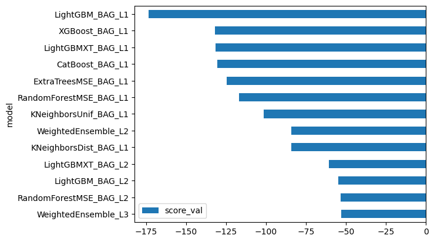

```python
predictor.leaderboard(silent=True).plot(kind="barh", x = "model", y ="score_val");
```

### Create predictions from test dataset

```python
predictions = predictor.predict(test)
predictions.head()
```

```
0    22.642460
1    42.650024
2    45.966980
3    48.724709
4    50.479599
Name: count, dtype: float32
```

#### NOTE: Kaggle will reject the submission if we don't set everything to be > 0.

```python
# Describe the `predictions` series to see if there are any negative values
predictions.describe()
```

```
count    6493.000000
mean      100.673820
std        90.043564
min         3.150023
25%        20.492958
50%        63.607239
75%       168.474915
max       366.942444
Name: count, dtype: float64
```

```python
# How many negative values do we have?
print((predictions < 0).sum())
```

```
0
```

```python
# Set them to zero
# but there is no negative values
```

### Set predictions to submission dataframe, save, and submit

```python
submission["count"] = predictions
submission.to_csv("submission.csv", index=False)
```

```python
!pip install Kaggle
```

```python
# Create the .kaggle directory and an empty kaggle.json file in your home directory
!mkdir -p ~/.kaggle
!touch ~/.kaggle/kaggle.json

# Set the correct permissions for the file
!chmod 600 ~/.kaggle/kaggle.json
```

```
The syntax of the command is incorrect.
```

```python
# Fill in your user name and key from creating the kaggle account and API token file
import json
import os

kaggle_username = "chitzin"
kaggle_key = "45f20c4d5ff85f949b22e6bf67460bbf"

kaggle_json_path = os.path.expanduser("~/.kaggle/kaggle.json")
kaggle_json_path

# Save API token the kaggle.json file
with open(kaggle_json_path, "w") as f:
    f.write(json.dumps({"username": kaggle_username, "key": kaggle_key}))
```

```python
!kaggle --version
```

```
Kaggle API 1.7.4.5
```

```python
!kaggle competitions submit -c bike-sharing-demand -f submission.csv -m "first raw submission"
```

```
Successfully submitted to Bike Sharing Demand
```

```
  8%|8         | 16.0k/195k [00:00<00:02, 66.6kB/s]
 58%|#####7    | 112k/195k [00:00<00:00, 400kB/s]
```

#### View submission via the command line or in the web browser under the competition's page - `My Submissions`

```python
!kaggle competitions submissions -c bike-sharing-demand | tail -n +1 | head -n 6
```

```
fileName                     date                        description                        status                     publicScore  privateScore
---------------------------  --------------------------  ---------------------------------  -------------------------  -----------  ------------
submission.csv               2025-05-25 16:26:46.420000  first raw submission               SubmissionStatus.COMPLETE  1.79544      1.79544
submission.csv               2025-05-25 15:31:08.940000  first raw submission               SubmissionStatus.COMPLETE  1.79359      1.79359
submission_new_hpo.csv       2025-05-24 20:41:40.607000  new features with hyperparameters  SubmissionStatus.COMPLETE  0.52169      0.52169
submission_new_hpo.csv       2025-05-24 20:37:28.327000  new features with hyperparameters  SubmissionStatus.ERROR
```

#### Initial score of `1.79544`

## Step 4: Exploratory Data Analysis and Creating an additional feature

- Any additional feature will do, but a great suggestion would be to separate out the datetime into hour, day, or month parts.

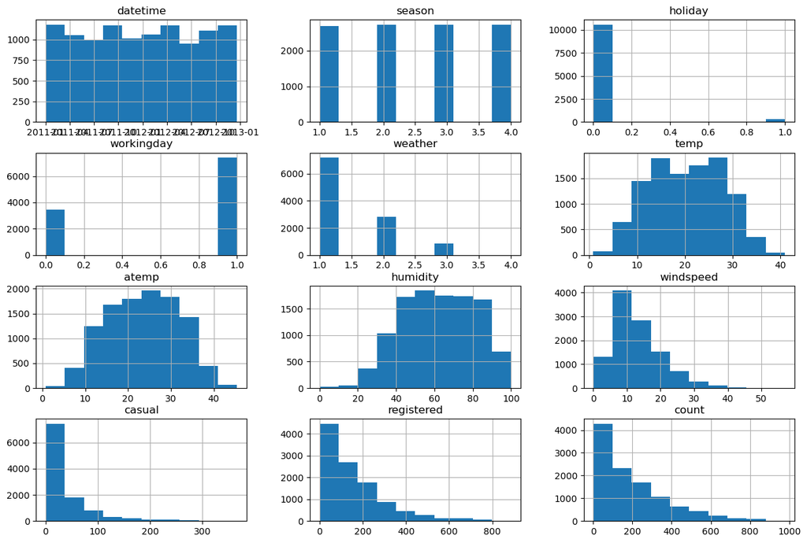

```python
# Create a histogram of all features to show the distribution of each one relative to the data. This is part of the exploritory data analysis
train.hist(figsize = (15,10));
```

```python
# create a new feature
train["datetime"] = pd.to_datetime(train["datetime"])
test["datetime"] = pd.to_datetime(test["datetime"])
```

```python
#separating out the datetime into hour, day, or month parts.
train["hour"] = train["datetime"].dt.hour
train["day"] = train["datetime"].dt.dayofweek
train["month"] = train["datetime"].dt.month
test["hour"] = test["datetime"].dt.hour
test["day"] = test["datetime"].dt.dayofweek
test["month"] = test["datetime"].dt.month
```

```python
train.drop(columns = "datetime", inplace= True)
test.drop(columns = "datetime", inplace= False)
```

|  | season | holiday | workingday | weather | temp | atemp | humidity | windspeed | hour | day | month |
| --- | --- | --- | --- | --- | --- | --- | --- | --- | --- | --- | --- |
| 0 | 1 | 0 | 1 | 1 | 10.66 | 11.365 | 56 | 26.0027 | 0 | 3 | 1 |
| 1 | 1 | 0 | 1 | 1 | 10.66 | 13.635 | 56 | 0.0000 | 1 | 3 | 1 |
| 2 | 1 | 0 | 1 | 1 | 10.66 | 13.635 | 56 | 0.0000 | 2 | 3 | 1 |
| 3 | 1 | 0 | 1 | 1 | 10.66 | 12.880 | 56 | 11.0014 | 3 | 3 | 1 |
| 4 | 1 | 0 | 1 | 1 | 10.66 | 12.880 | 56 | 11.0014 | 4 | 3 | 1 |
| ... | ... | ... | ... | ... | ... | ... | ... | ... | ... | ... | ... |
| 6488 | 1 | 0 | 1 | 2 | 10.66 | 12.880 | 60 | 11.0014 | 19 | 0 | 12 |
| 6489 | 1 | 0 | 1 | 2 | 10.66 | 12.880 | 60 | 11.0014 | 20 | 0 | 12 |
| 6490 | 1 | 0 | 1 | 1 | 10.66 | 12.880 | 60 | 11.0014 | 21 | 0 | 12 |
| 6491 | 1 | 0 | 1 | 1 | 10.66 | 13.635 | 56 | 8.9981 | 22 | 0 | 12 |
| 6492 | 1 | 0 | 1 | 1 | 10.66 | 13.635 | 65 | 8.9981 | 23 | 0 | 12 |

6493 rows × 11 columns

```python
train.head()
```

|  | season | holiday | workingday | weather | temp | atemp | humidity | windspeed | casual | registered | count | hour | day | month |
| --- | --- | --- | --- | --- | --- | --- | --- | --- | --- | --- | --- | --- | --- | --- |
| 0 | 1 | 0 | 0 | 1 | 9.84 | 14.395 | 81 | 0.0 | 3 | 13 | 16 | 0 | 5 | 1 |
| 1 | 1 | 0 | 0 | 1 | 9.02 | 13.635 | 80 | 0.0 | 8 | 32 | 40 | 1 | 5 | 1 |
| 2 | 1 | 0 | 0 | 1 | 9.02 | 13.635 | 80 | 0.0 | 5 | 27 | 32 | 2 | 5 | 1 |
| 3 | 1 | 0 | 0 | 1 | 9.84 | 14.395 | 75 | 0.0 | 3 | 10 | 13 | 3 | 5 | 1 |
| 4 | 1 | 0 | 0 | 1 | 9.84 | 14.395 | 75 | 0.0 | 0 | 1 | 1 | 4 | 5 | 1 |

```python
corr = train.corr()
pd.get_dummies(corr)
```

|  | season | holiday | workingday | weather | temp | atemp | humidity | windspeed | casual | registered | count | hour | day | month |
| --- | --- | --- | --- | --- | --- | --- | --- | --- | --- | --- | --- | --- | --- | --- |
| season | 1.000000 | 0.029368 | -0.008126 | 0.008879 | 0.258689 | 0.264744 | 0.190610 | -0.147121 | 0.096758 | 0.164011 | 0.163439 | -0.006546 | -0.010553 | 0.971524 |
| holiday | 0.029368 | 1.000000 | -0.250491 | -0.007074 | 0.000295 | -0.005215 | 0.001929 | 0.008409 | 0.043799 | -0.020956 | -0.005393 | -0.000354 | -0.191832 | 0.001731 |
| workingday | -0.008126 | -0.250491 | 1.000000 | 0.033772 | 0.029966 | 0.024660 | -0.010880 | 0.013373 | -0.319111 | 0.119460 | 0.011594 | 0.002780 | -0.704267 | -0.003394 |
| weather | 0.008879 | -0.007074 | 0.033772 | 1.000000 | -0.055035 | -0.055376 | 0.406244 | 0.007261 | -0.135918 | -0.109340 | -0.128655 | -0.022740 | -0.047692 | 0.012144 |
| temp | 0.258689 | 0.000295 | 0.029966 | -0.055035 | 1.000000 | 0.984948 | -0.064949 | -0.017852 | 0.467097 | 0.318571 | 0.394454 | 0.145430 | -0.038466 | 0.257589 |
| atemp | 0.264744 | -0.005215 | 0.024660 | -0.055376 | 0.984948 | 1.000000 | -0.043536 | -0.057473 | 0.462067 | 0.314635 | 0.389784 | 0.140343 | -0.040235 | 0.264173 |
| humidity | 0.190610 | 0.001929 | -0.010880 | 0.406244 | -0.064949 | -0.043536 | 1.000000 | -0.318607 | -0.348187 | -0.265458 | -0.317371 | -0.278011 | -0.026507 | 0.204537 |
| windspeed | -0.147121 | 0.008409 | 0.013373 | 0.007261 | -0.017852 | -0.057473 | -0.318607 | 1.000000 | 0.092276 | 0.091052 | 0.101369 | 0.146631 | -0.024804 | -0.150192 |
| casual | 0.096758 | 0.043799 | -0.319111 | -0.135918 | 0.467097 | 0.462067 | -0.348187 | 0.092276 | 1.000000 | 0.497250 | 0.690414 | 0.302045 | 0.246959 | 0.092722 |
| registered | 0.164011 | -0.020956 | 0.119460 | -0.109340 | 0.318571 | 0.314635 | -0.265458 | 0.091052 | 0.497250 | 1.000000 | 0.970948 | 0.380540 | -0.084427 | 0.169451 |
| count | 0.163439 | -0.005393 | 0.011594 | -0.128655 | 0.394454 | 0.389784 | -0.317371 | 0.101369 | 0.690414 | 0.970948 | 1.000000 | 0.400601 | -0.002283 | 0.166862 |
| hour | -0.006546 | -0.000354 | 0.002780 | -0.022740 | 0.145430 | 0.140343 | -0.278011 | 0.146631 | 0.302045 | 0.380540 | 0.400601 | 1.000000 | -0.002925 | -0.006818 |
| day | -0.010553 | -0.191832 | -0.704267 | -0.047692 | -0.038466 | -0.040235 | -0.026507 | -0.024804 | 0.246959 | -0.084427 | -0.002283 | -0.002925 | 1.000000 | -0.002266 |
| month | 0.971524 | 0.001731 | -0.003394 | 0.012144 | 0.257589 | 0.264173 | 0.204537 | -0.150192 | 0.092722 | 0.169451 | 0.166862 | -0.006818 | -0.002266 | 1.000000 |

```python
import seaborn as sns
import matplotlib.pyplot as plt
```

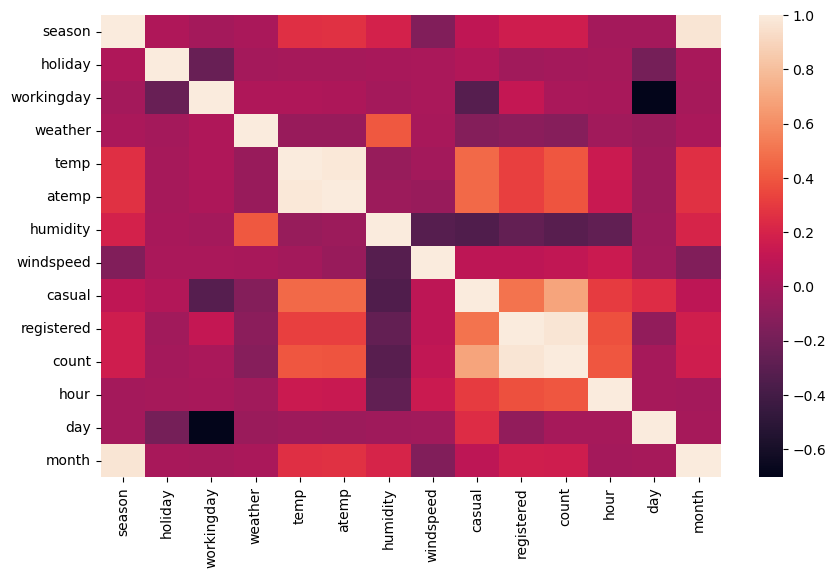

```python
corr = train.corr()
plt.figure(figsize=(10, 6))
sns.heatmap(corr);
```

Two independent variables "temp" and "atemp" are highly correlated. To reduce multicollinearity, we need to drop a column which is less correlated with the target value "count".

"Casual" and "Register" have high correlation with target. Therfore, we drop them while training model for "leaky error".

```python
train[["temp","count"]].corr()
```

|  | temp | count |
| --- | --- | --- |
| temp | 1.000000 | 0.394454 |
| count | 0.394454 | 1.000000 |

```python
train[["atemp","count"]].corr()
```

|  | atemp | count |
| --- | --- | --- |
| atemp | 1.000000 | 0.389784 |
| count | 0.389784 | 1.000000 |

```python
train.drop(columns = "atemp", inplace= True)
test.drop(columns = "atemp", inplace= True)
```

## Make category types for these so models know they are not just numbers

- AutoGluon originally sees these as ints, but in reality they are int representations of a category.
- Setting the dtype to category will classify these as categories in AutoGluon.

```python
train.info()
```

```
<class 'pandas.core.frame.DataFrame'>
RangeIndex: 10886 entries, 0 to 10885
Data columns (total 13 columns):
 #   Column      Non-Null Count  Dtype
---  ------      --------------  -----
 0   season      10886 non-null  int64
 1   holiday     10886 non-null  int64
 2   workingday  10886 non-null  int64
 3   weather     10886 non-null  int64
 4   temp        10886 non-null  float64
 5   humidity    10886 non-null  int64
 6   windspeed   10886 non-null  float64
 7   casual      10886 non-null  int64
 8   registered  10886 non-null  int64
 9   count       10886 non-null  int64
 10  hour        10886 non-null  int32
 11  day         10886 non-null  int32
 12  month       10886 non-null  int32
dtypes: float64(2), int32(3), int64(8)
memory usage: 978.2 KB
```

```python
train["season"] = train["season"].astype("category")
train["weather"] = train["weather"].astype("category")
test["season"] = test["season"].astype("category")
test["weather"] = test["weather"].astype("category")
```

```python
# View are new feature
test.info()
```

```
<class 'pandas.core.frame.DataFrame'>
RangeIndex: 6493 entries, 0 to 6492
Data columns (total 11 columns):
 #   Column      Non-Null Count  Dtype
---  ------      --------------  -----
 0   datetime    6493 non-null   datetime64[ns]
 1   season      6493 non-null   category
 2   holiday     6493 non-null   int64
 3   workingday  6493 non-null   int64
 4   weather     6493 non-null   category
 5   temp        6493 non-null   float64
 6   humidity    6493 non-null   int64
 7   windspeed   6493 non-null   float64
 8   hour        6493 non-null   int32
 9   day         6493 non-null   int32
 10  month       6493 non-null   int32
dtypes: category(2), datetime64[ns](1), float64(2), int32(3), int64(3)
memory usage: 393.7 KB
```

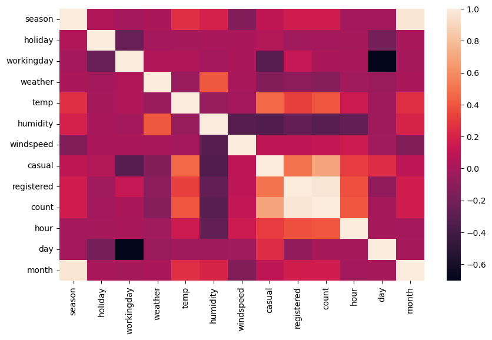

```python
corr = train.corr()
plt.figure(figsize=(10, 6))
sns.heatmap(corr);
```

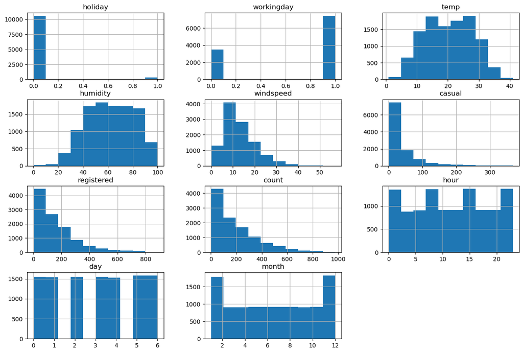

```python
# View histogram of all features again now with the hour feature
train.hist(figsize = (15,10));
```

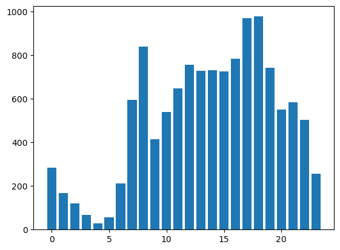

```python
# plotting a bar chart of day and count to analyze the data
plt.bar(train["hour"],train["count"]);
```

Between 7 am to 8 am for morning ,and 4 pm to 6 pm for evening has the highest renting rate.

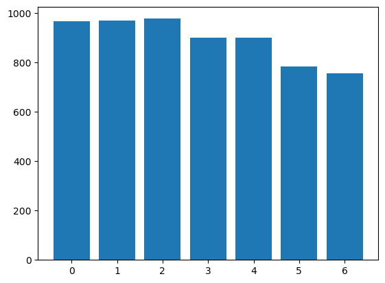

```python
plt.bar(train["day"],train["count"])# O for Monday and 6 for Sunday
plt.xticks(ticks = range(0,7));
```

## Step 5: Rerun the model with the same settings as before, just with more features

```python
predictor_new_features = TabularPredictor(label = "count",problem_type = "regression", eval_metric = "root_mean_squared_error").fit(train_data=train.drop(columns = ["casual","registered"]),
                                                               time_limit=600, presets="best_quality")
```

[output not shown]

[output cut: 201 more lines]

```
	15.96s	 = Training   runtime
	0.84s	 = Validation runtime
Fitting model: CatBoost_BAG_L2 ... Training model for up to 75.34s of the 75.18s of remaining time.
	Memory not enough to fit 8 folds in parallel. Will train 4 folds in parallel instead (Estimated 16.42% memory usage per fold, 65.68%/80.00% total).
	Fitting 8 child models (S1F1 - S1F8) | Fitting with ParallelLocalFoldFittingStrategy (4 workers, per: cpus=2, gpus=0, memory=16.42%)
	-54.1241	 = Validation score   (-root_mean_squared_error)
	67.53s	 = Training   runtime
	0.06s	 = Validation runtime
Fitting model: WeightedEnsemble_L3 ... Training model for up to 360.00s of the -0.23s of remaining time.
	Ensemble Weights: {'CatBoost_BAG_L2': 0.391, 'RandomForestMSE_BAG_L2': 0.261, 'LightGBM_BAG_L2': 0.174, 'LightGBMXT_BAG_L1': 0.087, 'LightGBM_BAG_L1': 0.087}
	-53.7446	 = Validation score   (-root_mean_squared_error)
	0.09s	 = Training   runtime
	0.0s	 = Validation runtime
AutoGluon training complete, total runtime = 433.56s ... Best model: WeightedEnsemble_L3 | Estimated inference throughput: 16.7 rows/s (1361 batch size)
TabularPredictor saved. To load, use: predictor = TabularPredictor.load("C:\Users\User\Downloads\cd0385-project-starter-main\cd0385-project-starter-main\project\AutogluonModels\ag-20250525_164505")
```

```python
predictor_new_features.fit_summary()
```

```
*** Summary of fit() ***
Estimated performance of each model:
                     model   score_val              eval_metric  pred_time_val    fit_time  pred_time_val_marginal  fit_time_marginal  stack_level  can_infer  fit_order
0      WeightedEnsemble_L3  -53.744632  root_mean_squared_error      84.001058  316.576583                0.000998           0.087765            3       True         14
1          CatBoost_BAG_L2  -54.124080  root_mean_squared_error      83.015831  293.192924                0.059748          67.531297            2       True         13
2          LightGBM_BAG_L2  -54.465398  root_mean_squared_error      83.097732  232.996986                0.141650           7.335359            2       True         11
3   RandomForestMSE_BAG_L2  -54.706822  root_mean_squared_error      83.798662  241.622162                0.842580          15.960535            2       True         12
4      WeightedEnsemble_L2  -54.770891  root_mean_squared_error      80.423808  214.457358                0.001994           0.089410            2       True          9
5        LightGBMXT_BAG_L2  -55.832365  root_mean_squared_error      83.642001  235.528000                0.685918           9.866373            2       True         10
6          LightGBM_BAG_L1  -56.276825  root_mean_squared_error      11.076133   23.636507               11.076133          23.636507            1       True          4
7        LightGBMXT_BAG_L1  -56.840615  root_mean_squared_error      69.238281   39.299159               69.238281          39.299159            1       True          3
8           XGBoost_BAG_L1  -59.576971  root_mean_squared_error       0.607458    3.695016                0.607458           3.695016            1       True          8
9          CatBoost_BAG_L1  -59.850842  root_mean_squared_error       0.107401  151.432282                0.107401         151.432282            1       True          6
10    ExtraTreesMSE_BAG_L1  -64.041381  root_mean_squared_error       0.829301    2.960864                0.829301           2.960864            1       True          7
11  RandomForestMSE_BAG_L1  -64.386497  root_mean_squared_error       0.838389    4.422347                0.838389           4.422347            1       True          5
12   KNeighborsDist_BAG_L1 -109.813073  root_mean_squared_error       0.139303    0.117682                0.139303           0.117682            1       True          2
13   KNeighborsUnif_BAG_L1 -113.226566  root_mean_squared_error       0.119817    0.097771                0.119817           0.097771            1       True          1
Number of models trained: 14
Types of models trained:
{'WeightedEnsembleModel', 'StackerEnsembleModel_CatBoost', 'StackerEnsembleModel_LGB', 'StackerEnsembleModel_XT', 'StackerEnsembleModel_RF', 'StackerEnsembleModel_XGBoost', 'StackerEnsembleModel_KNN'}
Bagging used: True  (with 8 folds)
Multi-layer stack-ensembling used: True  (with 3 levels)
Feature Metadata (Processed):
(raw dtype, special dtypes):
('category', [])  : 2 | ['season', 'weather']
('float', [])     : 2 | ['temp', 'windspeed']
('int', [])       : 4 | ['humidity', 'hour', 'day', 'month']
('int', ['bool']) : 2 | ['holiday', 'workingday']
Plot summary of models saved to file: C:\Users\User\Downloads\cd0385-project-starter-main\cd0385-project-starter-main\project\AutogluonModels\ag-20250525_164505\SummaryOfModels.html
*** End of fit() summary ***
```

[output not shown]

[output cut: 182 more lines]

```
     stack_level  can_infer  fit_order
 0             3       True         14
 1             2       True         13
 2             2       True         11
 3             2       True         12
 4             2       True          9
 5             2       True         10
 6             1       True          4
 7             1       True          3
 8             1       True          8
 9             1       True          6
 10            1       True          7
 11            1       True          5
 12            1       True          2
 13            1       True          1  }
```

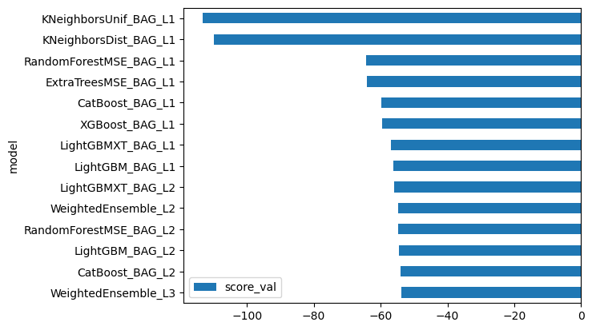

```python
predictor_new_features.leaderboard(silent=True).plot(kind="barh", x = "model", y ="score_val")
```

```python
# Remember to set all negative values to zero
predictions_new = predictor_new_features.predict(test)
print((predictions_new<0).sum())
```

```
10
```

```python
predictions_new[predictions_new<0] = 0
print((predictions_new<0).sum())
```

```
0
```

```python
submission_new_features = submission.copy()
```

```python
# Same submitting predictions
submission_new_features["count"] = predictions_new
submission_new_features.to_csv("submission_new_features.csv", index=False)
```

```python
submission_new_features.head()
```

|  | datetime | count |
| --- | --- | --- |
| 0 | 2011-01-20 00:00:00 | 25.757324 |
| 1 | 2011-01-20 01:00:00 | 5.013856 |
| 2 | 2011-01-20 02:00:00 | 3.812933 |
| 3 | 2011-01-20 03:00:00 | 2.764734 |
| 4 | 2011-01-20 04:00:00 | 2.572234 |

```python
!kaggle competitions submit -c bike-sharing-demand -f submission_new_features.csv -m "new features"
```

```
Successfully submitted to Bike Sharing Demand
```

```
  8%|8         | 16.0k/194k [00:00<00:05, 33.0kB/s]
 66%|######5   | 128k/194k [00:00<00:00, 259kB/s]
```

```python
!kaggle competitions submissions -c bike-sharing-demand | tail -n +1 | head -n 6
```

```
fileName                     date                        description                        status                     publicScore  privateScore
---------------------------  --------------------------  ---------------------------------  -------------------------  -----------  ------------
submission_new_features.csv  2025-05-25 17:01:01.570000  new features                       SubmissionStatus.COMPLETE  0.51763      0.51763
submission.csv               2025-05-25 16:26:46.420000  first raw submission               SubmissionStatus.COMPLETE  1.79544      1.79544
submission.csv               2025-05-25 15:31:08.940000  first raw submission               SubmissionStatus.COMPLETE  1.79359      1.79359
submission_new_hpo.csv       2025-05-24 20:41:40.607000  new features with hyperparameters  SubmissionStatus.COMPLETE  0.52169      0.52169
```

#### New Score of `0.51763`

## Step 6: Hyper parameter optimization

- There are many options for hyper parameter optimization.
- Options are to change the AutoGluon higher level parameters or the individual model hyperparameters.
- The hyperparameters of the models themselves that are in AutoGluon. Those need the `hyperparameter` and `hyperparameter_tune_kwargs` arguments.

```python
#setting hyperparameter
hyperparameters = {
    "NN_TORCH": {
        "n_epochs": 5, "learning_rate": 1e-2
    },
    "GBM": [{"extra_tree":True,"ag_args": {"name_suffix":"XT"}},{}, {
    "learning_rate": 0.03,
    "num_leaves": 128,
    "feature_fraction": 0.9,
    "min_data_in_leaf": 3,
    "ag_args": {"name_suffix": "Large", "priority": 0, "hyperparameter_tune_kwargs": None},
}],
    "KNN":{}
}

hyperparameters_tune_kwargs = {
    'num_trials' : 15,
    'scheduler' : 'local',
    'searcher':'auto'
}
```

```python
predictor_new_hpo = TabularPredictor(label = "count",problem_type = "regression", eval_metric = "root_mean_squared_error").fit(train_data=train.drop(columns = ["casual","registered"]),
                                                          hyperparameters = hyperparameters,hyperparameter_tune_kwargs = hyperparameters_tune_kwargs)
```

[output not shown]

```
[1000]	valid_set's rmse: 59.8927
[2000]	valid_set's rmse: 59.8767
```

```
	-59.766	 = Validation score   (-root_mean_squared_error)
	3.63s	 = Training   runtime
	0.08s	 = Validation runtime
Fitting model: WeightedEnsemble_L2 ...
	Ensemble Weights: {'LightGBMXT\T2': 0.538, 'LightGBMXT\T1': 0.462}
	-58.4412	 = Validation score   (-root_mean_squared_error)
	0.01s	 = Training   runtime
	0.0s	 = Validation runtime
AutoGluon training complete, total runtime = 486.5s ... Best model: WeightedEnsemble_L2 | Estimated inference throughput: 1501.5 rows/s (2178 batch size)
TabularPredictor saved. To load, use: predictor = TabularPredictor.load("C:\Users\User\Downloads\cd0385-project-starter-main\cd0385-project-starter-main\project\AutogluonModels\ag-20250525_170736")
```

```python
predictor_new_hpo.fit_summary()
```

```
*** Summary of fit() ***
Estimated performance of each model:
                  model   score_val              eval_metric  pred_time_val   fit_time  pred_time_val_marginal  fit_time_marginal  stack_level  can_infer  fit_order
0   WeightedEnsemble_L2  -58.441192  root_mean_squared_error       1.450530  14.892649                0.000998           0.013963            2       True         33
1         LightGBMXT\T2  -58.867082  root_mean_squared_error       0.430523   6.357357                0.430523           6.357357            1       True          3
2         LightGBMXT\T1  -59.023490  root_mean_squared_error       1.019010   8.521329                1.019010           8.521329            1       True          2
3         LightGBMXT\T6  -59.207257  root_mean_squared_error       2.497825  18.900562                2.497825          18.900562            1       True          7
4           LightGBM\T2  -59.383826  root_mean_squared_error       0.033909   1.544939                0.033909           1.544939            1       True         18
5          LightGBM\T11  -59.388792  root_mean_squared_error       0.388659   5.528789                0.388659           5.528789            1       True         27
6        LightGBMXT\T11  -59.475523  root_mean_squared_error       1.757835  14.264956                1.757835          14.264956            1       True         12
7           LightGBM\T4  -59.657051  root_mean_squared_error       0.963424  11.965468                0.963424          11.965468            1       True         20
8           LightGBM\T1  -59.679896  root_mean_squared_error       0.139627   2.034395                0.139627           2.034395            1       True         17
9         LightGBMLarge  -59.766007  root_mean_squared_error       0.081783   3.632194                0.081783           3.632194            1       True         32
10         LightGBM\T14  -59.794533  root_mean_squared_error       0.597207   6.062909                0.597207           6.062909            1       True         30
11         LightGBM\T13  -60.263438  root_mean_squared_error       0.520609   8.856879                0.520609           8.856879            1       True         29
12          LightGBM\T9  -60.310660  root_mean_squared_error       0.694592   7.811523                0.694592           7.811523            1       True         25
13         LightGBM\T12  -60.352446  root_mean_squared_error       0.704760  10.011912                0.704760          10.011912            1       True         28
14        LightGBMXT\T3  -60.413427  root_mean_squared_error       1.755578  12.528536                1.755578          12.528536            1       True          4
15        LightGBMXT\T8  -60.427156  root_mean_squared_error       0.605395   7.701607                0.605395           7.701607            1       True          9
16       LightGBMXT\T13  -60.497248  root_mean_squared_error       1.969196  15.198781                1.969196          15.198781            1       True         14
17          LightGBM\T3  -60.557329  root_mean_squared_error       0.080750   2.216612                0.080750           2.216612            1       True         19
18        LightGBMXT\T5  -60.565025  root_mean_squared_error       0.679055   8.158734                0.679055           8.158734            1       True          6
19        LightGBMXT\T7  -60.582176  root_mean_squared_error       0.514625   7.792472                0.514625           7.792472            1       True          8
20          LightGBM\T8  -60.624889  root_mean_squared_error       0.068872   1.573495                0.068872           1.573495            1       True         24
21       LightGBMXT\T14  -60.632765  root_mean_squared_error       0.765856   6.069125                0.765856           6.069125            1       True         15
22          LightGBM\T6  -60.643692  root_mean_squared_error       0.213429   4.204549                0.213429           4.204549            1       True         22
23         LightGBM\T15  -60.738285  root_mean_squared_error       0.743548   7.480953                0.743548           7.480953            1       True         31
24          LightGBM\T5  -61.004121  root_mean_squared_error       0.030918   1.286504                0.030918           1.286504            1       True         21
25          LightGBM\T7  -61.172028  root_mean_squared_error       0.034906   1.369156                0.034906           1.369156            1       True         23
26       LightGBMXT\T10  -61.204998  root_mean_squared_error       0.290226   4.663636                0.290226           4.663636            1       True         11
27        LightGBMXT\T9  -61.468051  root_mean_squared_error       1.853163  14.317560                1.853163          14.317560            1       True         10
28        LightGBMXT\T4  -61.705959  root_mean_squared_error       1.957608  14.656404                1.957608          14.656404            1       True          5
```

[output cut: 17 more lines]

[output not shown]

[output cut: 365 more lines]

```
 18       True          6
 19       True          8
 20       True         24
 21       True         15
 22       True         22
 23       True         31
 24       True         21
 25       True         23
 26       True         11
 27       True         10
 28       True          5
 29       True         26
 30       True         13
 31       True         16
 32       True          1  }
```

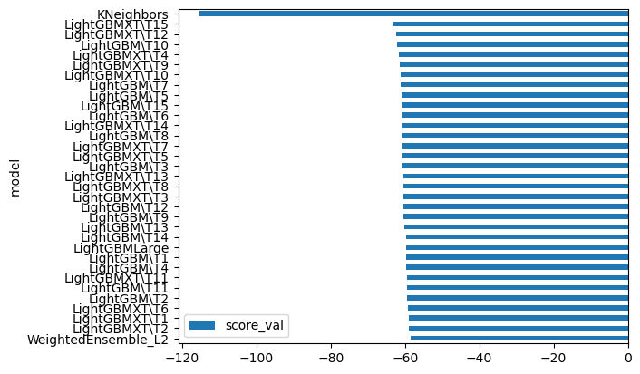

```python
predictor_new_hpo.leaderboard(silent=True).plot(kind="barh", x = "model", y ="score_val");
```

```python
# Remember to set all negative values to zero
predictions_hpo = predictor_new_hpo.predict(test)
print((predictions_hpo<0).sum())
```

```
334
```

```python
predictions_hpo[predictions_hpo<0] = 0
print((predictions_hpo<0).sum())
```

```
0
```

```python
submission_new_hpo = submission.copy()
```

```python
# Same submitting predictions
submission_new_hpo["count"] = predictions_hpo
submission_new_hpo.to_csv("submission_new_hpo.csv", index=False)
```

```python
!kaggle competitions submit -c bike-sharing-demand -f submission_new_hpo.csv -m "new features with hyperparameters"
```

```
Successfully submitted to Bike Sharing Demand
```

```
  8%|8         | 16.0k/193k [00:00<00:01, 92.3kB/s]
 75%|#######4  | 144k/193k [00:00<00:00, 542kB/s]
```

```python
!kaggle competitions submissions -c bike-sharing-demand | tail -n +1 | head -n 6
```

```
fileName                     date                        description                        status                     publicScore  privateScore
---------------------------  --------------------------  ---------------------------------  -------------------------  -----------  ------------
submission_new_hpo.csv       2025-05-25 17:24:21.920000  new features with hyperparameters  SubmissionStatus.COMPLETE  0.82784      0.82784
submission_new_features.csv  2025-05-25 17:01:01.570000  new features                       SubmissionStatus.COMPLETE  0.51763      0.51763
submission.csv               2025-05-25 16:26:46.420000  first raw submission               SubmissionStatus.COMPLETE  1.79544      1.79544
submission.csv               2025-05-25 15:31:08.940000  first raw submission               SubmissionStatus.COMPLETE  1.79359      1.79359
```

#### New Score of `0.82784`

## Step 7: Write a Report

### Refer to the markdown file for the full report

### Creating plots and table for report

```python
predictor.leaderboard(silent=True)["score_val"][0]
```

```
-53.12267893276294
```

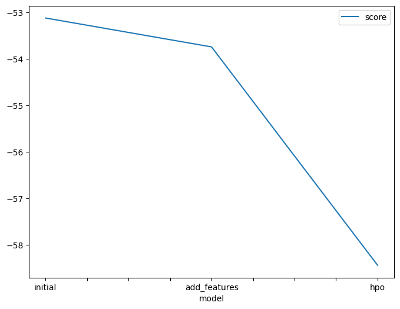

```python
# Taking the top model score from each training run and creating a line plot to show improvement
# You can create these in the notebook and save them to PNG or use some other tool (e.g. google sheets, excel)
fig = pd.DataFrame(
    {
        "model": ["initial", "add_features", "hpo"],
        "score": [predictor.leaderboard(silent=True)["score_val"][0],#the model's `score_val` while training
                  predictor_new_features.leaderboard(silent=True)["score_val"][0],
                  predictor_new_hpo.leaderboard(silent=True)["score_val"][0]]
    }
).plot(x="model", y="score", figsize=(8, 6)).get_figure()
fig.savefig('model_train_score.png')
```

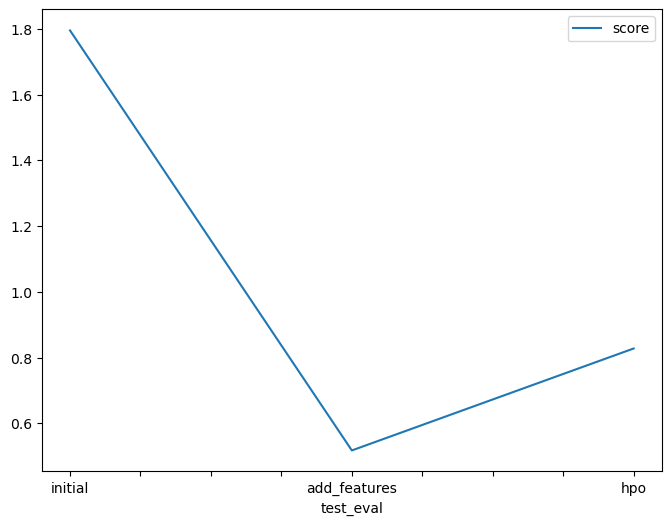

```python
# Take the 3 kaggle scores and creating a line plot to show improvement
fig = pd.DataFrame(
    {
        "test_eval": ["initial", "add_features", "hpo"],
        "score": [1.79544 ,0.51763 ,0.82784 ]#score on test data
    }
).plot(x="test_eval", y="score", figsize=(8, 6)).get_figure()
fig.savefig('model_test_score.png')
```

### Hyperparameter table

```python
# The 3 hyperparameters we tuned with the kaggle score as the result
pd.DataFrame({
    "model": ["initial", "add_features", "hpo"],
    "hpo1": ["default_values", "default_values", "NN_TORCH"],
    "hpo2": ["default_values""default_values""default_values""default_values""default_values", "default_values""default_values", "GBM"],
    "hpo3": ["default_values""default_values""default_values""default_values", "default_values""default_values""default_values", "KNN"],
    "score": [1.79544 ,0.51763 ,0.82784 ]
})
```

[output not shown]